# Introduction to KoNLP API

Heewon Jeon

2016-11-15

This page is for showing simple example about KoNLP with some Hangul.

# Introduction to KoNLP API

## extractNoun

function for extract Nouns from sentences. Internally, runs pos tagger and only select Noun from set.

```r
library(KoNLP)
useSystemDic()
```

```
## Backup was just finished!
## 283949 words dictionary was built.
```

```r
extractNoun("롯데마트가 판매하고 있는 흑마늘 양념 치킨이 논란이 되고 있다.")
```

```
## [1] "롯데마트가" "판매"       "흑마늘"     "양념"       "치킨"
## [6] "논란"
```

```r
sapply(c("R은 free 소프트웨어이고, [완전하게 무보증]입니다.", "일정한 조건에 따르면, 자유롭게 이것을 재배포할수가 있습니다."), extractNoun)
```

```
##      R은 free 소프트웨어이고, [완전하게 무보증]입니다.
## [1,] "R"
## [2,] "free"
## [3,] "소프트웨어"
## [4,] "완전"
## [5,] "무보"
## [6,] "증"
##      일정한 조건에 따르면, 자유롭게 이것을 재배포할수가 있습니다.
## [1,] "일정"
## [2,] "한"
## [3,] "조건"
## [4,] "자유"
## [5,] "이것"
## [6,] "재배포할수가"
```

## SimplePos09

This function returns pos tagged terms using KAIST tag set only using 9 main tags.

```r
pos <- SimplePos09("롯데마트가 판매하고 있는 흑마늘 양념 치킨이 논란이 되고 있다.")
pos
```

```
## $롯데마트가
## [1] "롯데마트가/N"
##
## $판매하고
## [1] "판매/N+하고/J"
##
## $있는
## [1] "있/P+는/E"
##
## $흑마늘
## [1] "흑마늘/N"
##
## $양념
## [1] "양념/N"
##
## $치킨이
## [1] "치킨/N+이/J"
##
## $논란이
## [1] "논란/N+이/J"
##
## $되고
## [1] "되/P+고/E"
##
## $있다
## [1] "있/P+다/E"
##
## $.
## [1] "./S"
```

```r
pos$`롯데마트가`
```

```
## [1] "롯데마트가/N"
```

## SimplePos22

This is similar with SimplePos09 but using more detail 22 tag set.

```r
SimplePos22("롯데마트가 판매하고 있는 흑마늘 양념 치킨이 논란이 되고 있다.")
```

```
## $롯데마트가
## [1] "롯데마트가/NC"
##
## $판매하고
## [1] "판매/NC+하고/JC"
##
## $있는
## [1] "있/PX+는/ET"
##
## $흑마늘
## [1] "흑마늘/NC"
##
## $양념
## [1] "양념/NC"
##
## $치킨이
## [1] "치킨/NC+이/JC"
##
## $논란이
## [1] "논란/NC+이/JC"
##
## $되고
## [1] "되/PV+고/EC"
##
## $있다
## [1] "있/PX+다/EF"
##
## $.
## [1] "./SF"
```

## MorphAnalyzer

show morph analysis result.

```r
MorphAnalyzer("롯데마트가 판매하고 있는 흑마늘 양념 치킨이 논란이 되고 있다.")
```

```
## $롯데마트가
## [1] "롯데마트/ncn+가/jcc" "롯데마트/ncn+가/jcs" "롯데마트가/ncn"
## [4] "롯데마트/nqq+가/jcc" "롯데마트/nqq+가/jcs" "롯데마트가/nqq"
##
## $판매하고
## [1] "판매/ncpa+하고/jcj"             "판매/ncpa+하고/jct"
## [3] "판매/ncpa+하/xsva+고/ecc"       "판매/ncpa+하/xsva+고/ecs"
## [5] "판매/ncpa+하/xsva+고/ecx"       "판매/ncpa+하/xsva+어/ef+고/jcr"
##
## $있는
## [1] "있/paa+는/etm" "있/px+는/etm"
##
## $흑마늘
## [1] "흑마늘/ncn" "흑마늘/nqq"
##
## $양념
## [1] "양념/ncn"
##
## $치킨이
## [1] "치킨/ncn+이/jcc" "치킨/ncn+이/jcs" "치킨/ncn+이/ncn"
##
## $논란이
## [1] "논란/ncpa+이/jcc" "논란/ncpa+이/jcs" "논란/ncpa+이/ncn"
##
## $되고
##  [1] "되/nbu+고/jcj"       "되/nbu+이/jp+고/ecc" "되/nbu+이/jp+고/ecs"
##  [4] "되/nbu+이/jp+고/ecx" "되/paa+고/ecc"       "되/paa+고/ecs"
##  [7] "되/paa+고/ecx"       "되/pvg+고/ecc"       "되/pvg+고/ecs"
## [10] "되/pvg+고/ecx"       "되/px+고/ecc"        "되/px+고/ecs"
## [13] "되/px+고/ecx"
##
## $있다
## [1] "있/paa+다/ef" "있/px+다/ef"
##
## $.
## [1] "./sf" "./sy"
```

## Tag information

Mindmap of KAIST tag set .

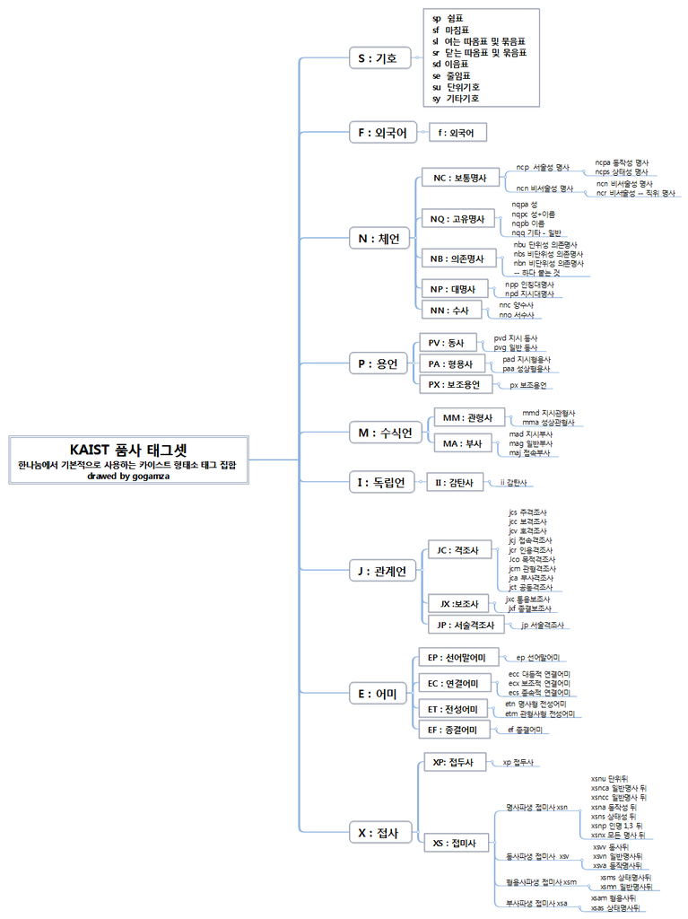

*will provide English version of tag set as soon as possible*

original tag was taken from [Hannanum reference manual](http://semanticweb.kaist.ac.kr/home/index.php/HanNanum).

## convertHangulStringToJamos

convert Hangul string to Jamo(Korean alphabet) string. return will be char vector with each syllable.

```r
convertHangulStringToJamos("R는 많은 공헌자에의한 공동 프로젝트입니다")
```

```
##  [1] "R"      "ㄴㅡㄴ" " "      "ㅁㅏㄶ" "ㅇㅡㄴ" " "      "ㄱㅗㅇ"
##  [8] "ㅎㅓㄴ" "ㅈㅏ"   "ㅇㅔ"   "ㅇㅢ"   "ㅎㅏㄴ" " "      "ㄱㅗㅇ"
## [15] "ㄷㅗㅇ" " "      "ㅍㅡ"   "ㄹㅗ"   "ㅈㅔㄱ" "ㅌㅡ"   "ㅇㅣㅂ"
## [22] "ㄴㅣ"   "ㄷㅏ"
```

## convertHangulStringToKeyStrokes

Hangul string to keyboard strokes(2-bul). Strokes char will be full-width ascii character.

```r
convertHangulStringToKeyStrokes("R는 많은 공헌자에의한 공동 프로젝트입니다")
```

```
##  [1] "R"        "ｓｍｓ"   " "        "ａｋｓｇ" "ｄｍｓ"   " "
##  [7] "ｒｈｄ"   "ｇｊｓ"   "ｗｋ"     "ｄｐ"     "ｄｍｌ"   "ｇｋｓ"
## [13] " "        "ｒｈｄ"   "ｅｈｄ"   " "        "ｖｍ"     "ｆｈ"
## [19] "ｗｐｒ"   "ｘｍ"     "ｄｌｑ"   "ｓｌ"     "ｅｋ"
```

## HangulAutomata

Convert from Jamo(or keystroke) sequences to Hangul syllables.

```r
str <- convertHangulStringToJamos("배포 조건의 상세한것에 대해서는 'license()' 또는 'licence()' 라고 입력해주십시오")
str2 <-paste(str, collapse="")
str2
```

```
## [1] "ㅂㅐㅍㅗ ㅈㅗㄱㅓㄴㅇㅢ ㅅㅏㅇㅅㅔㅎㅏㄴㄱㅓㅅㅇㅔ ㄷㅐㅎㅐㅅㅓㄴㅡㄴ 'license()' ㄸㅗㄴㅡㄴ 'licence()' ㄹㅏㄱㅗ ㅇㅣㅂㄹㅕㄱㅎㅐㅈㅜㅅㅣㅂㅅㅣㅇㅗ"
```

```r
HangulAutomata(str2)
```

```
## [1] "배포 조건의 상세한것에 대해서는 'license()' 또는 'licence()' 라고 입력해주십시오"
```

## useSejongDic, useSystemDic

change to Sejong, Hannanum System, NIADic.

```r
useSystemDic()
```

```
## Backup was just finished!
## 283949 words dictionary was built.
```

```r
extractNoun("성긴털제비꽃은 너무 예쁘다.")
```

```
## [1] "성긴털제비꽃은"
```

```r
SimplePos09("성긴털제비꽃은 너무 예쁘다.")
```

```
## $성긴털제비꽃은
## [1] "성긴털제비꽃은/N"
##
## $너무
## [1] "너무/M"
##
## $예쁘다
## [1] "예쁘/P+다/E"
##
## $.
## [1] "./S"
```

```r
SimplePos22("성긴털제비꽃은 너무 예쁘다.")
```

```
## $성긴털제비꽃은
## [1] "성긴털제비꽃은/NC"
##
## $너무
## [1] "너무/MA"
##
## $예쁘다
## [1] "예쁘/PA+다/EF"
##
## $.
## [1] "./SF"
```

```r
MorphAnalyzer("성긴털제비꽃은 너무 예쁘다.")
```

```
## $성긴털제비꽃은
## [1] "성긴털제비꽃/ncn+은/jxc" "성긴털제비꽃은/ncn"
## [3] "성긴털제비꽃/nqq+은/jxc" "성긴털제비꽃은/nqq"
##
## $너무
## [1] "너무/mag"
##
## $예쁘다
## [1] "예쁘/paa+다/ef"
##
## $.
## [1] "./sf" "./sy"
```

```r
useSejongDic()
```

```
## Backup was just finished!
## 370957 words dictionary was built.
```

```r
extractNoun("성긴털제비꽃은 너무 예쁘다.")
```

```
## [1] "성긴털제비꽃"
```

```r
SimplePos09("성긴털제비꽃은 너무 예쁘다.")
```

```
## $성긴털제비꽃은
## [1] "성긴털제비꽃/N+은/J"
##
## $너무
## [1] "너무/M"
##
## $예쁘다
## [1] "예쁘/P+다/E"
##
## $.
## [1] "./S"
```

```r
SimplePos22("성긴털제비꽃은 너무 예쁘다.")
```

```
## $성긴털제비꽃은
## [1] "성긴털제비꽃/NC+은/JX"
##
## $너무
## [1] "너무/MA"
##
## $예쁘다
## [1] "예쁘/PA+다/EF"
##
## $.
## [1] "./SF"
```

```r
MorphAnalyzer("성긴털제비꽃은 너무 예쁘다.")
```

```
## $성긴털제비꽃은
## [1] "성긴털제비꽃/ncn+은/jxc" "성긴털제비꽃/ncn+은/ncn"
##
## $너무
## [1] "너무/mag"
##
## $예쁘다
## [1] "예쁘/paa+다/ef"
##
## $.
## [1] "./sf" "./sy"
```

```r
useNIADic()
```

```
## Backup was just finished!
## 983012 words dictionary was built.
```

```r
extractNoun("성긴털제비꽃은 너무 예쁘다.")
```

```
## [1] "성긴털" "제비꽃"
```

```r
SimplePos09("성긴털제비꽃은 너무 예쁘다.")
```

```
## $성긴털제비꽃은
## [1] "성긴털제비꽃/N+은/J"
##
## $너무
## [1] "너무/M"
##
## $예쁘다
## [1] "예쁘/P+다/E"
##
## $.
## [1] "./S"
```

```r
SimplePos22("성긴털제비꽃은 너무 예쁘다.")
```

```
## $성긴털제비꽃은
## [1] "성긴털제비꽃/NC+은/JX"
##
## $너무
## [1] "너무/MA"
##
## $예쁘다
## [1] "예쁘/PA+다/EF"
##
## $.
## [1] "./SF"
```

```r
MorphAnalyzer("성긴털제비꽃은 너무 예쁘다.")
```

```
## $성긴털제비꽃은
##  [1] "성긴털/ncn+제비꽃/ncn+은/jxc"
##  [2] "성긴털/ncn+제비꽃/ncn+은/ncn"
##  [3] "성긴털/ncn+제비꽃/ncn+은/ncn"
##  [4] "성긴털/ncn+제비꽃/ncn+은/jcs"
##  [5] "성긴털/ncn+제비/ncn+꽃/ncn+은/jxc"
##  [6] "성긴털/ncn+제비/ncn+꽃/ncn+은/jcs"
##  [7] "성긴털/ncn+제비/ncn+꽃/ncn+은/jxc"
##  [8] "성긴털/ncn+제비/ncn+꽃/ncn+은/jcs"
##  [9] "성긴털/ncn+제비/ncn+꽃/ncn+은/jxc"
## [10] "성긴털/ncn+제비/ncn+꽃/ncn+은/jcs"
## [11] "성긴털/ncn+제비/ncn+꽃/ncn+은/jxc"
## [12] "성긴털/ncn+제비/ncn+꽃/ncn+은/jcs"
##
## $너무
## [1] "너무/mag"
##
## $예쁘다
## [1] "예쁘/paa+다/ef"
##
## $.
## [1] "./sf" "./sy" "./sf"
```

## buildDictionary

User can make own dictionary using NIAdic and Sejong additional packages.

```r
txt <- '미국 싱크탱크 전략국제문제연구소(CSIS)의 빅터 차 한국석좌는 9일(현지시간) 미국의 제45대 대통령으로 당선된 도널드 트럼프가 전시작전통제권(전작권)을 한국에 조기에 넘길 가능성이 있다고 전망했다.'


buildDictionary(ext_dic = c('sejong', 'woorimalsam'),user_dic = data.frame(term="전작권", tag='ncn'), category_dic_nms=c('political'))
```

```
## 718106 words dictionary was built.
```

```r
extractNoun(txt)
```

```
##  [1] "미국"                     "싱크탱크"
##  [3] "전략국제문제연구소(CSIS)" "빅터"
##  [5] "차"                       "한국"
##  [7] "석좌"                     "9일(현지시간)"
##  [9] "미국"                     "제45대"
## [11] "대통령"                   "당선"
## [13] "도널드"                   "트럼프"
## [15] "전시"                     "작전"
## [17] "통제"                     "전작권"
## [19] "한국"                     "조기"
## [21] "가능성"                   "전망"
```

## Use buildDictionary for mergeUserDic (mergeUserDic is deprecated)

Function can be usually used for appending new terms to user dictionary.

```r
useSystemDic()
```

```
## Backup was just finished!
## 283949 words dictionary was built.
```

```r
buildDictionary(ext_dic = "",user_dic = data.frame("삼성전자", "ncn"), replace_usr_dic = T)
```

```
## 283950 words dictionary was built.
```

```r
extractNoun("삼성전자에서는 아이폰에 대항할 무기를 준비하고 있다.")
```

[output not shown]

```r
buildDictionary(ext_dic = "",user_dic=data.frame("아이폰", "ncn"),replace_usr_dic = F)
```

```
## 283951 words dictionary was built.
```

```r
extractNoun("삼성전자에서는 아이폰에 대항할 무기를 준비하고 있다.")
```

```
## [1] "삼성전자" "아이폰에" "대항"     "무기"     "준비"
```

```r
# get dictionary as data.frame
head(get_dictionary('user_dic'))
```

```
##       term tag
## 1 삼성전자 ncn
## 2   아이폰 ncn
```

# Examples

## Wordcloud example

Example will draw wordcloud after analyze Korean famous novel named “광장_최인훈”(can’t include novel cause copyright, but you can find other good txt files).

1. read txt file.
2. parse using extractNoun().
3. draw wordcloud with word frequency

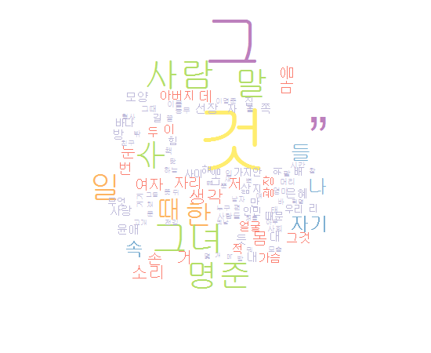

wordcloud

## Korean Twitter Analysis

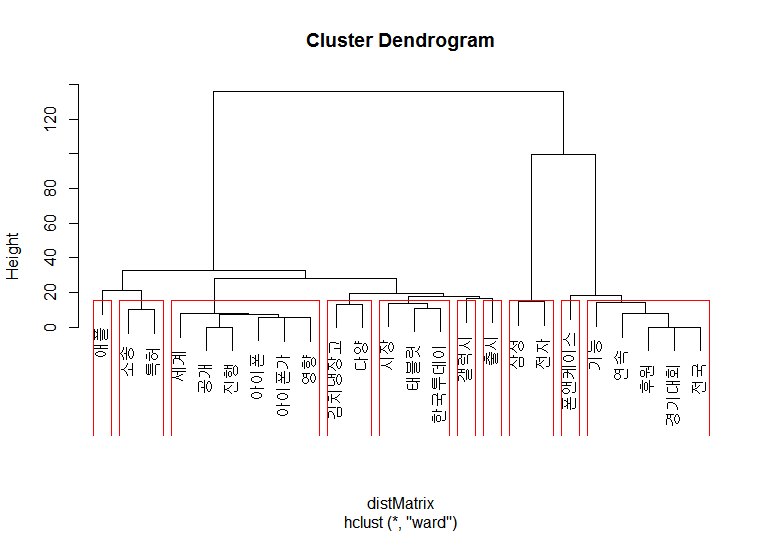

dendrogram

```r
#referenced from http://www.rdatamining.com/

## @knitr init
library(twitteR)
#
# n <- 200
#
# keyword <- "삼성전자"
#
# keyword <- enc2utf8(keyword)
#
# rdmTweets <- searchTwitter(keyword,  n)

load(url("http://dl.dropbox.com/u/8686172/twitter.RData"))

nDocs <- length(rdmTweets)



## @knitr preprocess
library(KoNLP)
library(tm)


df <- do.call("rbind", lapply(rdmTweets, as.data.frame))

removeTwit <- function(x) {gsub("@[[:graph:]]*", "", x)}

df$ptext <- sapply(df$text, removeTwit)

removeURL <- function(x) { gsub("http://[[:graph:]]*", "", x)}

df$ptext <- sapply(df$ptext, removeURL)
useSejongDic()
df$ptext <- sapply(df$ptext, function(x) {paste(extractNoun(x), collapse=" ")})

#build corpus
myCorpus_ <- Corpus(VectorSource(df$ptext))
myCorpus_ <- tm_map(myCorpus_, removePunctuation)
myCorpus_ <- tm_map(myCorpus_, removeNumbers)
myCorpus_ <- tm_map(myCorpus_, tolower)
myStopwords <- c(stopwords('english'), "rt")
myCorpus_ <-tm_map(myCorpus_, removeWords, myStopwords)



## @knitr eda

myTdm <- TermDocumentMatrix(myCorpus, control=list(wordLengths=c(2,Inf)))

#inspect frequent term
findFreqTerms(myTdm, lowfreq=10)

#inspect associations
findAssocs(myTdm,'lg',0.25)


## @knitr barplot
library(ggplot2)

termFrequency <- rowSums(as.matrix(myTdm))
termFrequency <- subset(termFrequency,termFrequency>=10)

ggplot(data.frame(term = names(termFrequency), freq=termFrequency), aes(term, freq)) + geom_bar() + coord_flip()


## @knitr wordcloud
#Word Cloud

library(wordcloud)

m <- as.matrix(myTdm)

wordFreq <- sort(rowSums(m),decreasing=TRUE)

set.seed(375)

pal <- brewer.pal(8,"Dark2")

wordcloud(words=names(wordFreq),freq=wordFreq,min.freq=10,random.order=F, rot.per=.1,colors=pal)



## @knitr hclust
myTdm2<-removeSparseTerms(myTdm,sparse=0.95)
m2<-as.matrix(myTdm2)

distMatrix<-dist(scale(m2))

fit<-hclust(distMatrix,method="ward")

plot(fit)

rect.hclust(fit,k=10)

#(groups<-cutree(fit,k=10))



## @knitr kmeans
m3 <- t(m2)
k <- 4
kmres <- kmeans(m3, k)

round(kmres$centers, digits=3)


for(i in 1:k){
  cat(paste("cluster ", i, " : ", sep=""))
  s <- sort(kmres$centers[i, ], decreasing=T)
  cat(names(s)[1:3], "\n")
  #print(head(rdmTweets[which(kmres$cluster ==i)],n=3))
}


## @knitr kmedoid
library(fpc)
pamResult <- pamk(m3, metric="manhattan")
(k <- pamResult$nc)

pamResult <- pamResult$pamobject
#print cluster medoids

for(i in 1:k){
  cat(paste("cluster",i,":"))
  cat(colnames(pamResult$medoids)[which(pamResult$medoids[i,]==1)],"\n")
  # print tweets in cluster i
  #print(rdmTweets[pamResult$clustering==i])
}
```